```r
source('C:/Users/owenj/OneDrive/Uni/Vacation Scholarship/GEKI_Vacation_Scholarship/src/mcmc_normal.R')
```

```r
plot_trace_plots <- function(chain.1, chain.2, burnin = 0, iterations = 1e4) {

  par(mfrow = c(1,2))

  plot(chain.1[(burnin + 1):iterations, 1], type = 'l', main = 'alpha')
  lines(chain.2[(burnin + 1):iterations, 1], col = 'red')

  plot(chain.1[(burnin + 1):iterations, 2], type = 'l', main = 'sigma2')
  lines(chain.2[(burnin + 1):iterations, 2], col = 'red')
}
```

```r
plot_histogram <- function(chain.1, chain.2, true_params, burnin = 0,
                           iterations = 1e4) {
  chain.1.burnin <- chain.1[(burnin + 1): iterations, ]
  chain.2.burnin <- chain.2[(burnin + 1): iterations, ]
  combined_chains <- rbind(chain.1.burnin, chain.2.burnin)

  par(mfrow = c(1,2))
  hist(combined_chains[, 1], freq = F, main = 'alpha')
  abline(v = true_params$alpha, col = 'red')
  hist(combined_chains[, 2], freq = F, main = 'sigma2')
  abline(v = log(true_params$sigma**2), col = 'red')

}
```

# Results For Multivariate Normal Model

## The Model

We assume that we have access to a single observation from a multivariate normal distribution $y \sim N(\alpha x, \sigma^2I)$ where $\alpha$ is a scalar and $x$ is a known vector. The unknown parameters in this model are $\theta = (\alpha, \sigma^2)$.

I look at a range of combinations of $\alpha, x$ and $\sigma^2$, comparing against MCMC sampling. Of particular interest is how well GEKI is able to estimate the noise parameter, since previous EKI algorithms require the noise parameter to be known.

In all combinations we draw from the same priors:

- $\alpha \sim ~ N(0, 5^2)$
- $\log(\sigma^2) \sim N(0, 2^2)$

```r
prior_params = list(alpha.mean = 0, alpha.sd = 5, sigma2.sd = 2, sigma2.mean = 0)
```

## Changing Number of Dimensions

In this experiment I keep $\alpha$ and $\sigma^2$ fixed at 2 and 4 respectively and let $x$ be a vector of 1s corresponding to 10, 50 and 100 dimensions. The purpose of this is to see how the EKI algorithm performs when the number of dimensions increases.

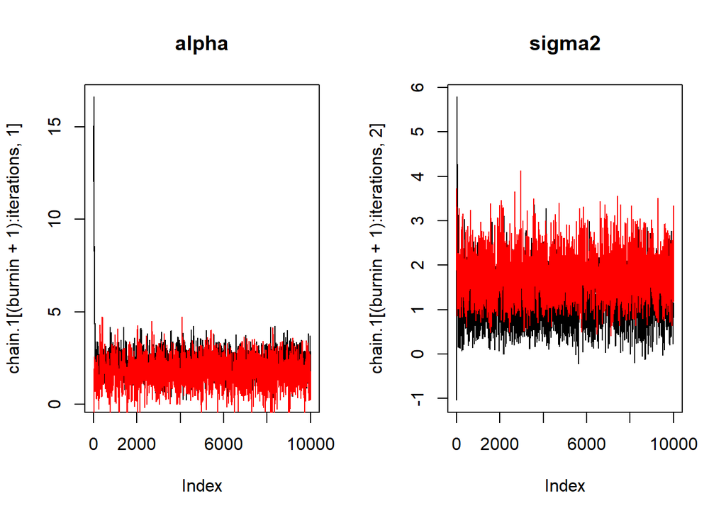

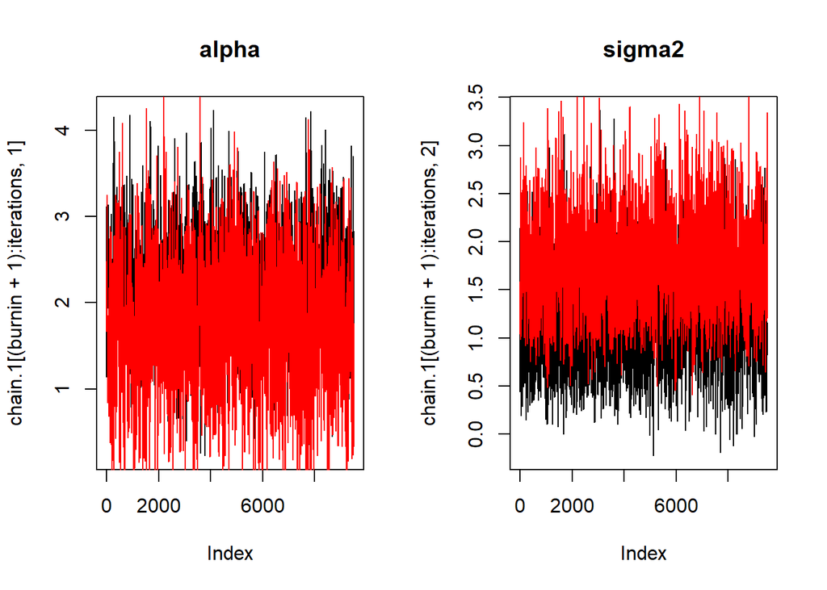

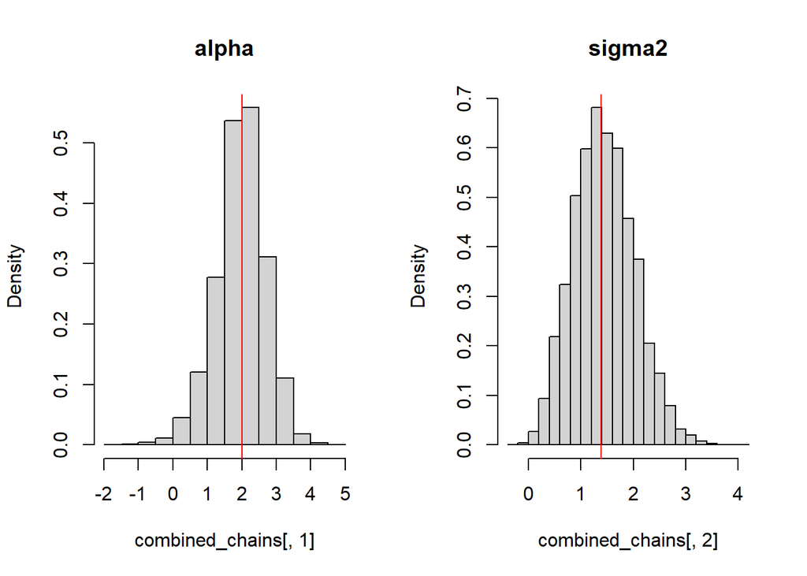

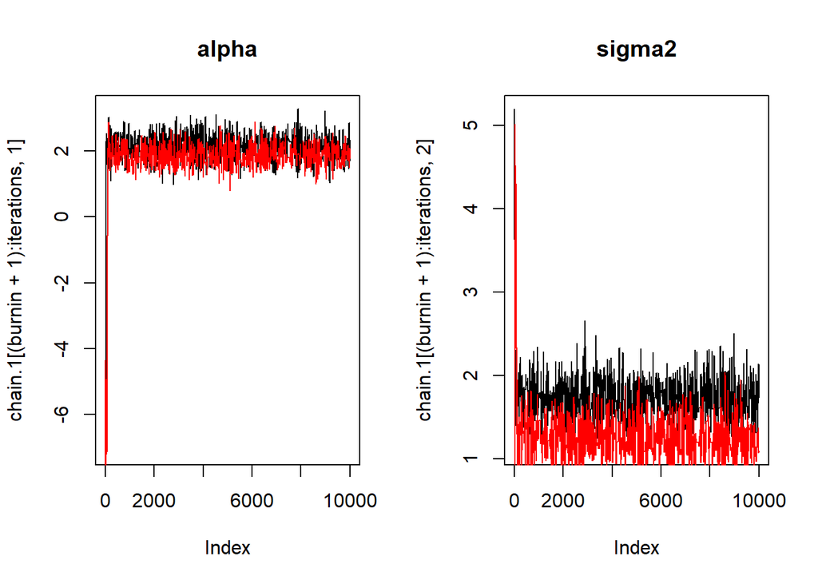

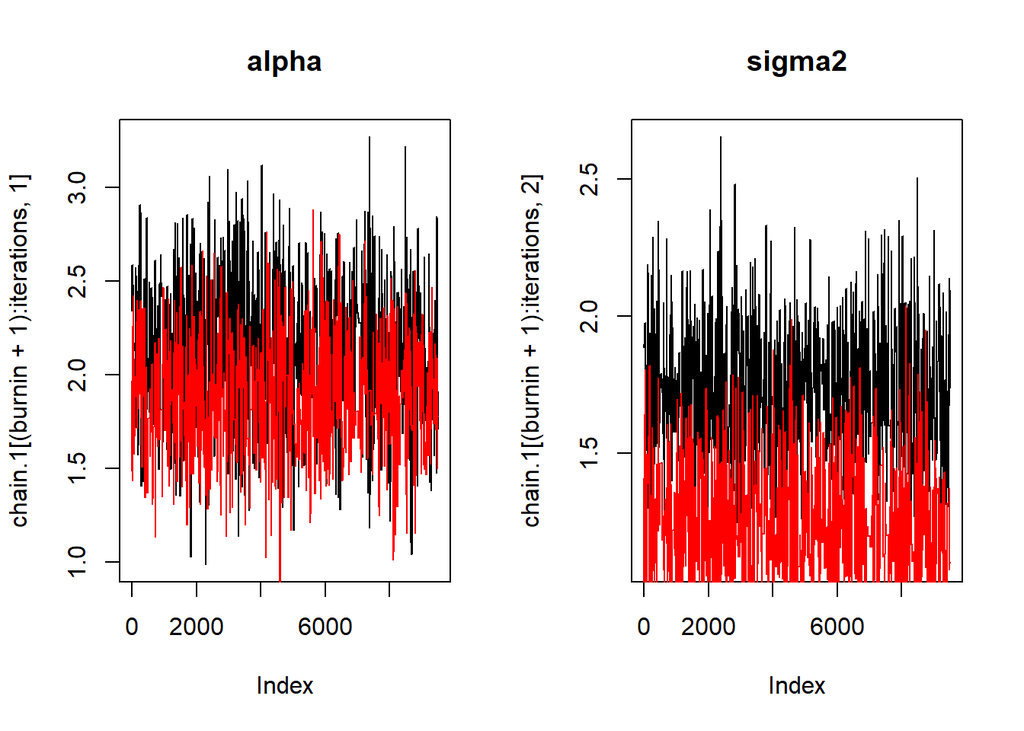

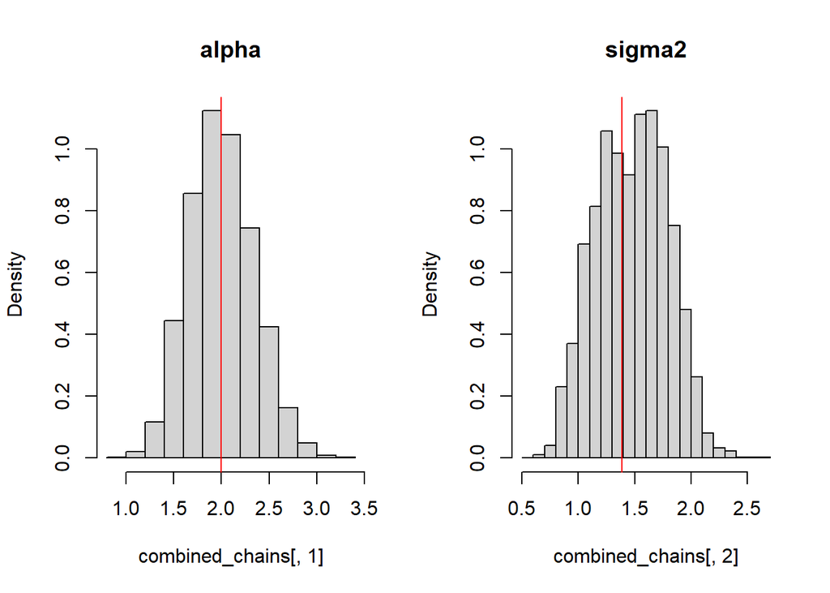

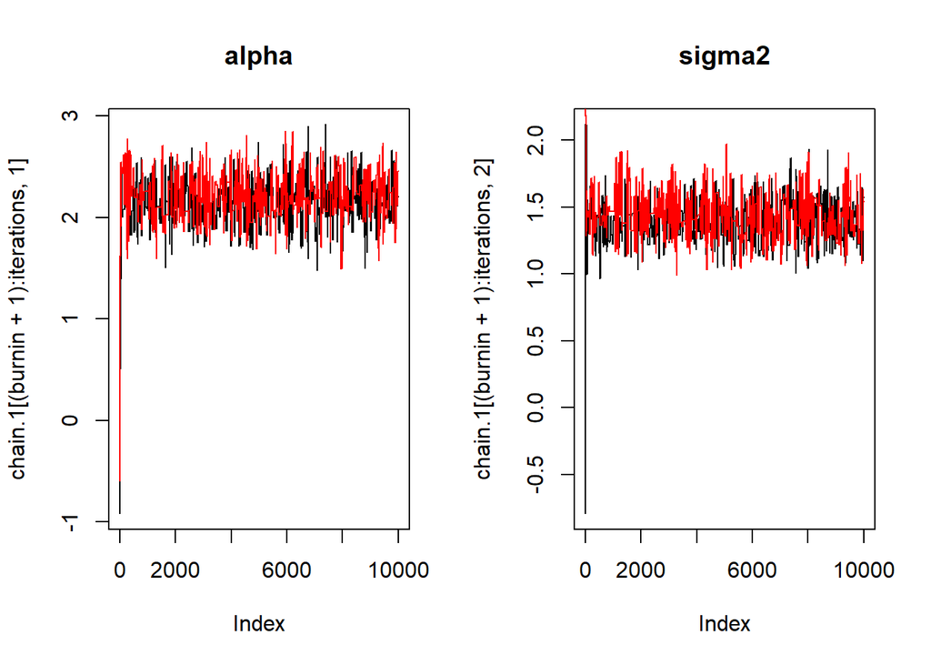

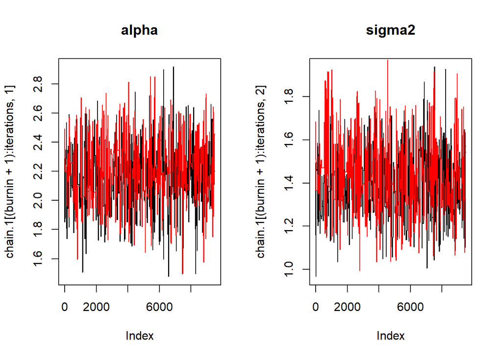

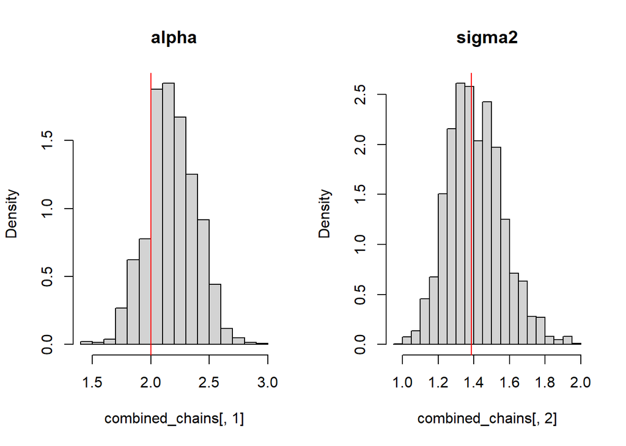

```r
num_dimensions <- c(10, 50, 100)
for (dimension in num_dimensions) {
  true_params = list(alpha = 2, sigma = 2, x = rep(1, dimension))
  run.1 <- normal_mcmc(true_params, prior_params)
  chain.1 <- run.1$batch
  run.2 <- normal_mcmc(true_params, prior_params)
  chain.2 <- run.2$batch
  plot_trace_plots(chain.1, chain.2)
  plot_trace_plots(chain.1, chain.2, 500)
  plot_histogram(chain.1, chain.2, true_params, 500)
}
```

## Changing $\alpha$

In this experiment, I keep $\sigma^2$ fixed at 4, make $x$ a 50-dimensional vector of 1s and change $\alpha$ from 0 to 10 in increments of 2. The purpose of this is to make sure that the EKI algorithm is accurate across of range of $\alpha$ and if it changes how the noise parameter is estimated.

```r
alpha_seq <- seq(0, 10, length.out = 6)
```

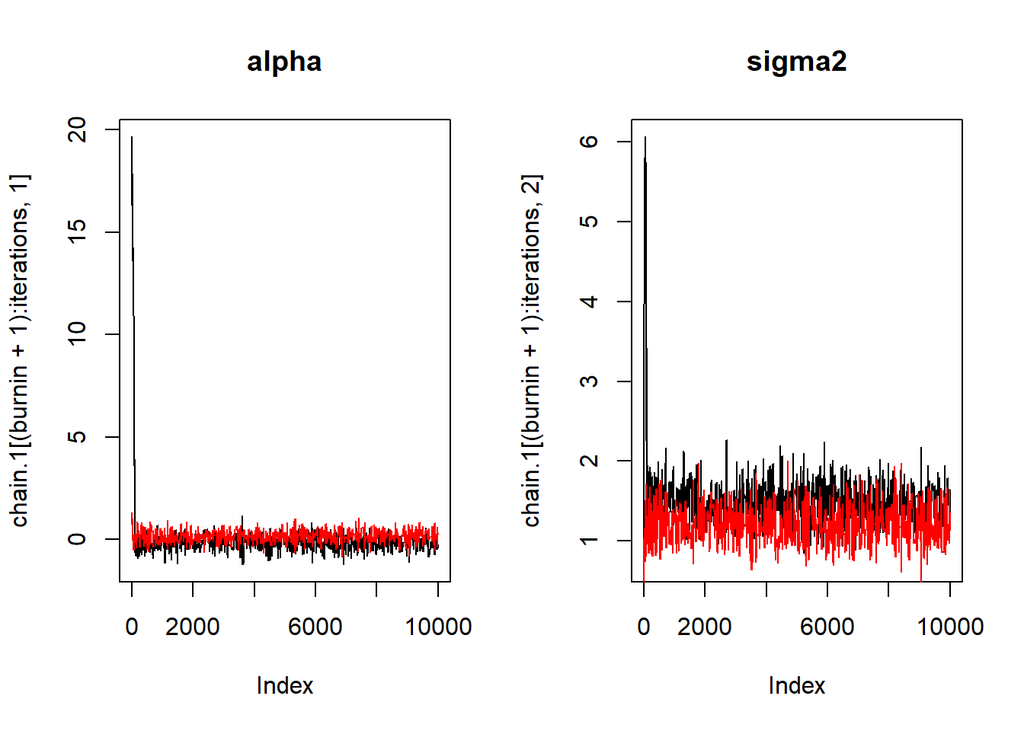

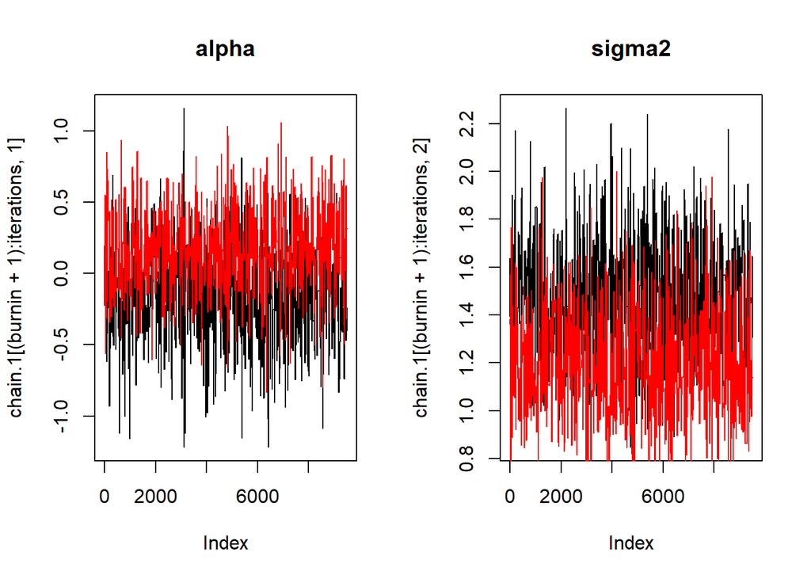

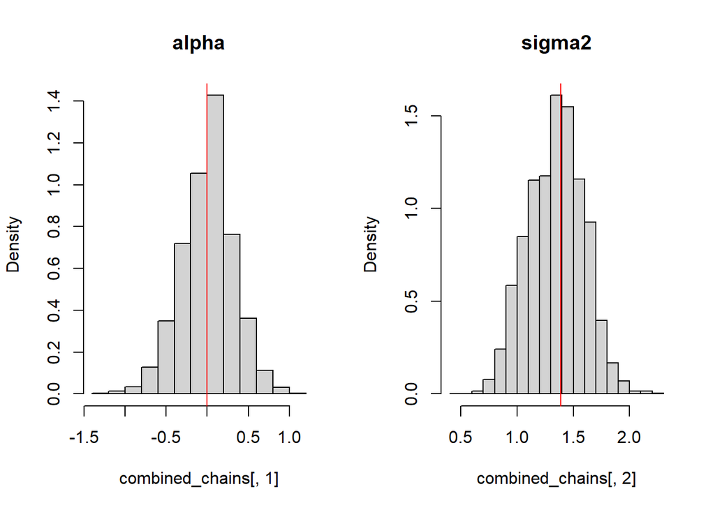

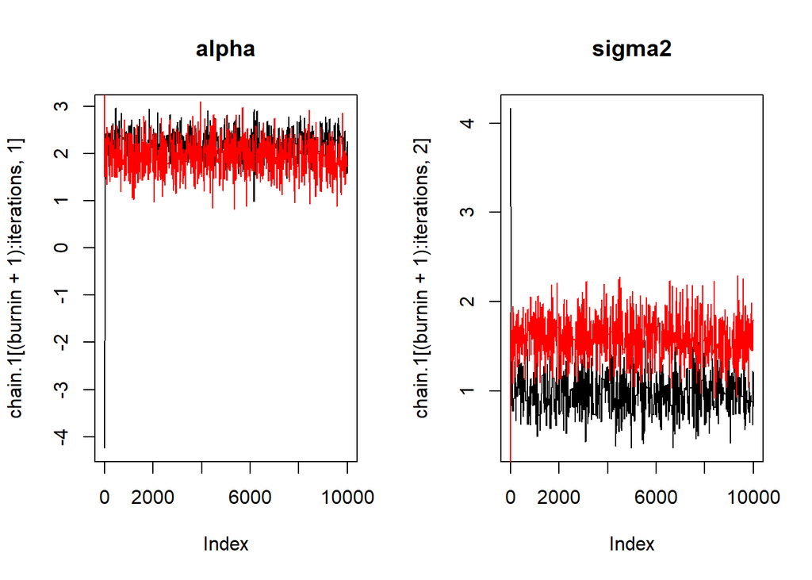

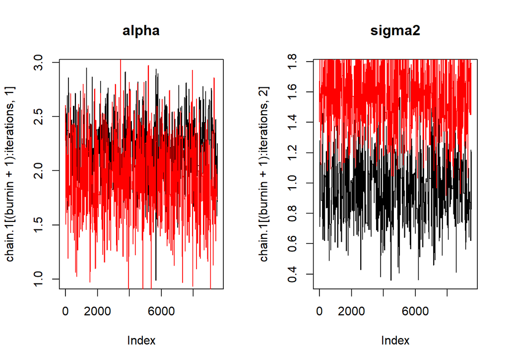

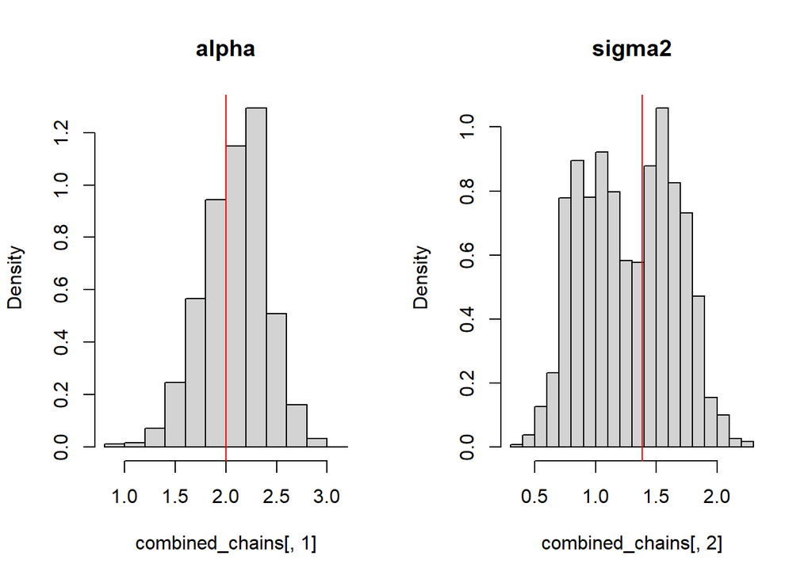

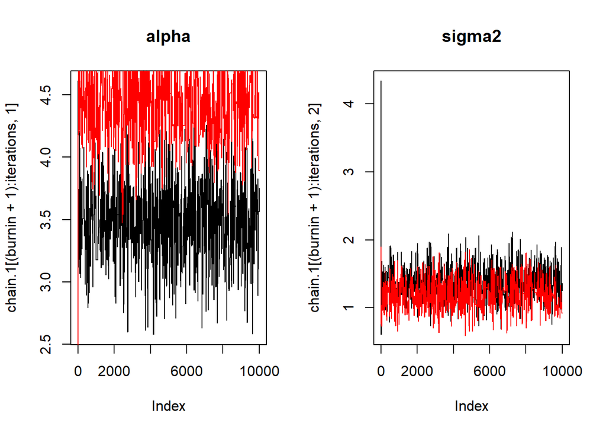

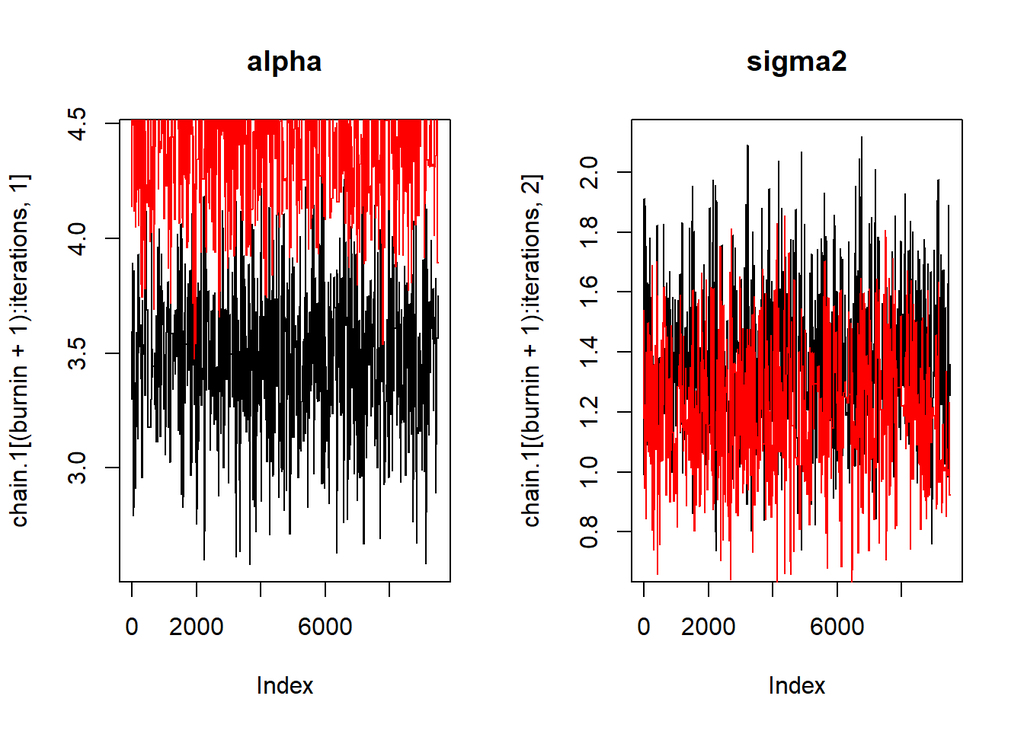

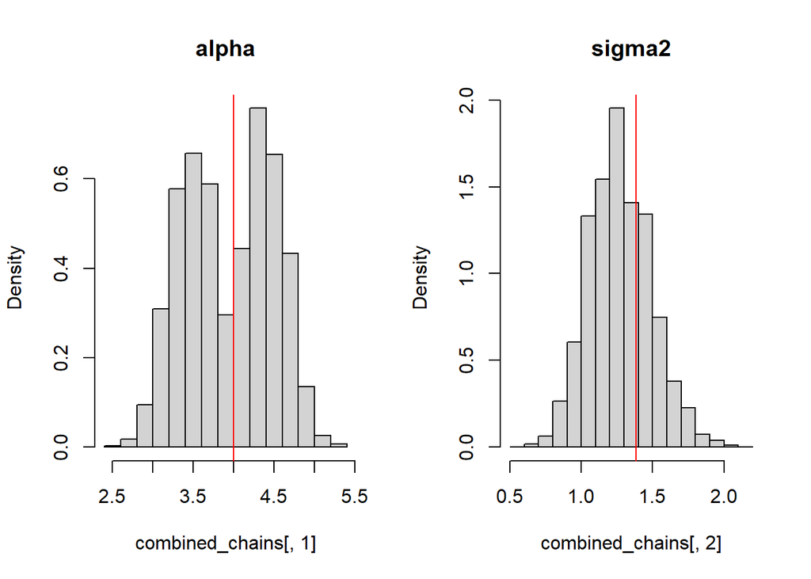

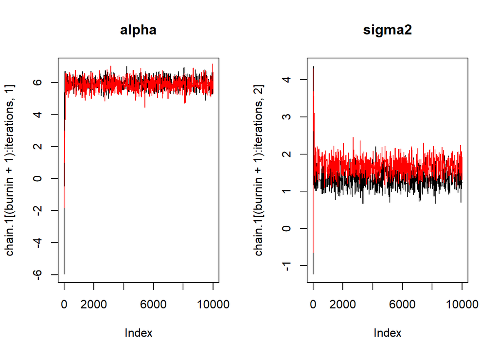

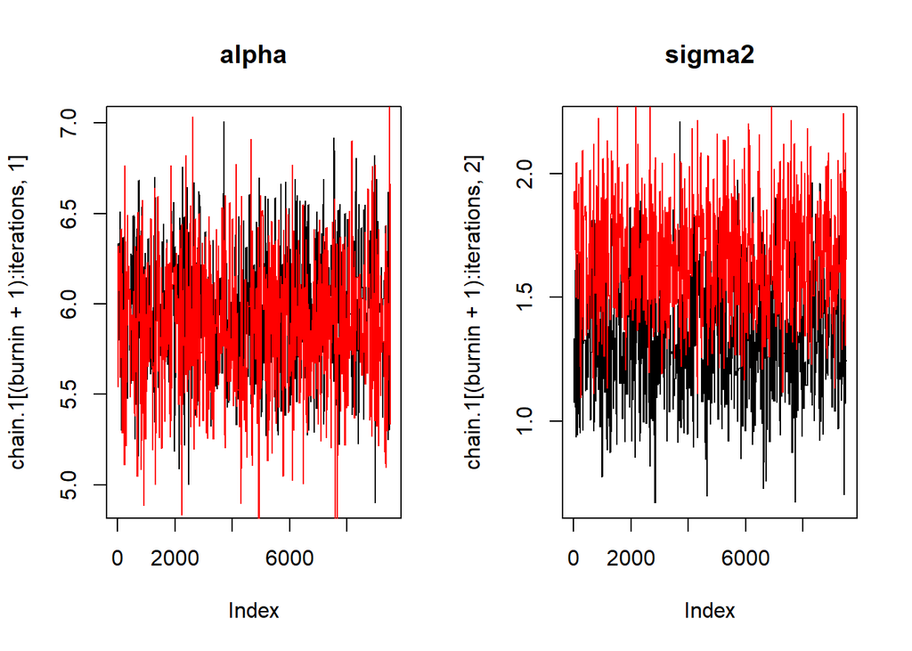

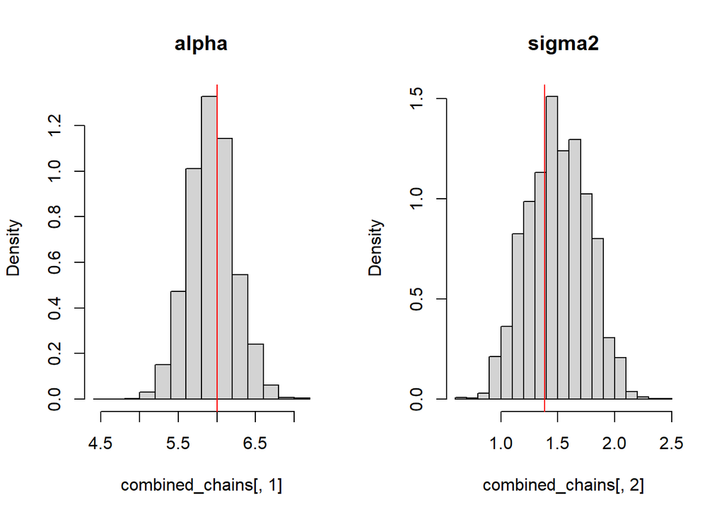

[6 more figures not shown]

```r
num_dimensions <- 50
for (alpha in alpha_seq) {

  true_params <- list(alpha = alpha, sigma = 2,
                          x = rep(1, num_dimensions))
  run.1 <- normal_mcmc(true_params, prior_params)
  chain.1 <- run.1$batch
  run.2 <- normal_mcmc(true_params, prior_params)
  chain.2 <- run.2$batch
  plot_trace_plots(chain.1, chain.2)
  plot_trace_plots(chain.1, chain.2, 500)
  plot_histogram(chain.1, chain.2, true_params, 500)

}
```

## Changing $\sigma^2$

```r
sigma_seq <- seq(2, 10, length.out = 5)
```